# PCA Notebook

Denaldo Lapi, Samy Chouti, Franscesco Aristei

27 March 2022

```r
# delete R objects left in memory
rm(list = ls())
```

Then we load the needed packages:

```r
library(dplyr)
library(kableExtra) # for viz
library(HSAUR3)
library(readr)
```

## Exploratory data analysis

Let’s load and inspect the dataset

```r
# load the data
cars = read.csv("cars2004.csv")
```

```r
# inspect the dataset
head(cars)
```

|  | Name | Sports | SUV | Wagon | Minivan | Pickup | AWD | RWD | Retail | Dealer | Engine | Cylinders | Horsepower | CityMPG | HighwayMPG | Weight | WheelBase | Length | Width |
| --- | --- | --- | --- | --- | --- | --- | --- | --- | --- | --- | --- | --- | --- | --- | --- | --- | --- | --- | --- |
| 1 | Chevrolet Aveo 4dr | 0 | 0 | 0 | 0 | 0 | 0 | 0 | 11690 | 10965 | 1.6 | 4 | 103 | 28 | 34 | 2370 | 98 | 167 | 66 |
| 2 | Chevrolet Aveo LS 4dr hatch | 0 | 0 | 0 | 0 | 0 | 0 | 0 | 12585 | 11802 | 1.6 | 4 | 103 | 28 | 34 | 2348 | 98 | 153 | 66 |
| 3 | Chevrolet Cavalier 2dr | 0 | 0 | 0 | 0 | 0 | 0 | 0 | 14610 | 13697 | 2.2 | 4 | 140 | 26 | 37 | 2617 | 104 | 183 | 69 |
| 4 | Chevrolet Cavalier 4dr | 0 | 0 | 0 | 0 | 0 | 0 | 0 | 14810 | 13884 | 2.2 | 4 | 140 | 26 | 37 | 2676 | 104 | 183 | 68 |
| 5 | Chevrolet Cavalier LS 2dr | 0 | 0 | 0 | 0 | 0 | 0 | 0 | 16385 | 15357 | 2.2 | 4 | 140 | 26 | 37 | 2617 | 104 | 183 | 69 |
| 6 | Dodge Neon SE 4dr | 0 | 0 | 0 | 0 | 0 | 0 | 0 | 13670 | 12849 | 2.0 | 4 | 132 | 29 | 36 | 2581 | 105 | 174 | 67 |

Now, it is useful to visualize the data in a tabular fashion with the Kable library and with the pipe operator. We show only 5 rows since there are 428 total rows

```r
cars[1:5 ,] %>%
kbl(caption = "Cars models") %>%
kable_classic(full_width = F, html_font = "Cambria")
```

Cars models

| Name | Sports | SUV | Wagon | Minivan | Pickup | AWD | RWD | Retail | Dealer | Engine | Cylinders | Horsepower | CityMPG | HighwayMPG | Weight | WheelBase | Length | Width |
| --- | --- | --- | --- | --- | --- | --- | --- | --- | --- | --- | --- | --- | --- | --- | --- | --- | --- | --- |
| Chevrolet Aveo 4dr | 0 | 0 | 0 | 0 | 0 | 0 | 0 | 11690 | 10965 | 1.6 | 4 | 103 | 28 | 34 | 2370 | 98 | 167 | 66 |
| Chevrolet Aveo LS 4dr hatch | 0 | 0 | 0 | 0 | 0 | 0 | 0 | 12585 | 11802 | 1.6 | 4 | 103 | 28 | 34 | 2348 | 98 | 153 | 66 |
| Chevrolet Cavalier 2dr | 0 | 0 | 0 | 0 | 0 | 0 | 0 | 14610 | 13697 | 2.2 | 4 | 140 | 26 | 37 | 2617 | 104 | 183 | 69 |
| Chevrolet Cavalier 4dr | 0 | 0 | 0 | 0 | 0 | 0 | 0 | 14810 | 13884 | 2.2 | 4 | 140 | 26 | 37 | 2676 | 104 | 183 | 68 |
| Chevrolet Cavalier LS 2dr | 0 | 0 | 0 | 0 | 0 | 0 | 0 | 16385 | 15357 | 2.2 | 4 | 140 | 26 | 37 | 2617 | 104 | 183 | 69 |

```r
dim(cars)
```

```
[1] 428  19
```

The dataset consists of 428 cars from the 2004 model year and 19 features. The first feature is the name of the car (variable Name). Apart from that, seven features are binary indicators; the other 11 features are numerical, i.e. continuous.

Since our goal is to apply the PCA algorithm , which works with continuous data, the binary variables will be treated as supplementary qualitative variables; specifically, we will use them to identify specific clusters of data points as we will see later.

Now it can be useful to visualize some selected rows and columns:

```r
cars %>% slice(c(10,25)) %>%
                kbl() %>%
                 kable_classic(full_width = F, html_font = "Cambria")
```

| Name | Sports | SUV | Wagon | Minivan | Pickup | AWD | RWD | Retail | Dealer | Engine | Cylinders | Horsepower | CityMPG | HighwayMPG | Weight | WheelBase | Length | Width |
| --- | --- | --- | --- | --- | --- | --- | --- | --- | --- | --- | --- | --- | --- | --- | --- | --- | --- | --- |
| Ford Focus SE 4dr | 0 | 0 | 0 | 0 | 0 | 0 | 0 | 15460 | 14496 | 2.0 | 4 | 130 | 26 | 33 | 2606 | 103 | 168 | 67 |
| Kia Spectra GS 4dr hatch | 0 | 0 | 0 | 0 | 0 | 0 | 0 | 13580 | 12830 | 1.8 | 4 | 124 | 24 | 32 | 2686 | 101 | 178 | 68 |

Let’s see a brief summary of the main statistics of the dataset:

```r
summary(cars)
```

```
     Name               Sports             SUV             Wagon            Minivan            Pickup             AWD
 Length:428         Min.   :0.00000   Min.   :0.0000   Min.   :0.00000   Min.   :0.00000   Min.   :0.00000   Min.   :0.000
 Class :character   1st Qu.:0.00000   1st Qu.:0.0000   1st Qu.:0.00000   1st Qu.:0.00000   1st Qu.:0.00000   1st Qu.:0.000
 Mode  :character   Median :0.00000   Median :0.0000   Median :0.00000   Median :0.00000   Median :0.00000   Median :0.000
                    Mean   :0.08081   Mean   :0.1402   Mean   :0.07009   Mean   :0.04673   Mean   :0.05607   Mean   :0.215
                    3rd Qu.:0.00000   3rd Qu.:0.0000   3rd Qu.:0.00000   3rd Qu.:0.00000   3rd Qu.:0.00000   3rd Qu.:0.000
                    Max.   :1.00000   Max.   :1.0000   Max.   :1.00000   Max.   :1.00000   Max.   :1.00000   Max.   :1.000
                    NA's   :32
      RWD            Retail           Dealer           Engine        Cylinders        Horsepower       CityMPG
 Min.   :0.000   Min.   : 10280   Min.   :  9875   Min.   :1.300   Min.   :-1.000   Min.   : 73.0   Min.   :10.00
 1st Qu.:0.000   1st Qu.: 20334   1st Qu.: 18866   1st Qu.:2.375   1st Qu.: 4.000   1st Qu.:165.0   1st Qu.:17.00
 Median :0.000   Median : 27635   Median : 25295   Median :3.000   Median : 6.000   Median :210.0   Median :19.00
 Mean   :0.257   Mean   : 32775   Mean   : 30015   Mean   :3.197   Mean   : 5.776   Mean   :215.9   Mean   :20.09
 3rd Qu.:1.000   3rd Qu.: 39205   3rd Qu.: 35710   3rd Qu.:3.900   3rd Qu.: 6.000   3rd Qu.:255.0   3rd Qu.:21.00
 Max.   :1.000   Max.   :192465   Max.   :173560   Max.   :8.300   Max.   :12.000   Max.   :500.0   Max.   :60.00
                                                                                                    NA's   :14
   HighwayMPG        Weight       WheelBase         Length          Width
 Min.   :12.00   Min.   :1850   Min.   : 89.0   Min.   :143.0   Min.   :64.00
 1st Qu.:24.00   1st Qu.:3102   1st Qu.:103.0   1st Qu.:177.0   1st Qu.:69.00
 Median :26.00   Median :3474   Median :107.0   Median :186.0   Median :71.00
 Mean   :26.91   Mean   :3577   Mean   :108.2   Mean   :185.1   Mean   :71.29
 3rd Qu.:29.00   3rd Qu.:3974   3rd Qu.:112.0   3rd Qu.:193.0   3rd Qu.:73.00
 Max.   :66.00   Max.   :7190   Max.   :144.0   Max.   :227.0   Max.   :81.00
 NA's   :14      NA's   :2      NA's   :2       NA's   :26      NA's   :28
```

## Preproccessing

Before proceeding in the exploration of the data, it is important to understand the quality of the dataset, looking for example if there are NA values and outliers.

### Missing values

We can see from the above summary that many columns contain NA values, therefore we should solve this problem.

Let’s look at the sum and the mean of the NA values in each column.

```r
print("Number of NA values in each column:")
```

```
[1] "Number of NA values in each column:"
```

```r
for(name in names(cars)){
  print(paste(name,  ": ", sum(is.na(cars[, name]))))
}
```

```
[1] "Name :  0"
[1] "Sports :  32"
[1] "SUV :  0"
[1] "Wagon :  0"
[1] "Minivan :  0"
[1] "Pickup :  0"
[1] "AWD :  0"
[1] "RWD :  0"
[1] "Retail :  0"
[1] "Dealer :  0"
[1] "Engine :  0"
[1] "Cylinders :  0"
[1] "Horsepower :  0"
[1] "CityMPG :  14"
[1] "HighwayMPG :  14"
[1] "Weight :  2"
[1] "WheelBase :  2"
[1] "Length :  26"
[1] "Width :  28"
```

```r
print("--------------------------------------------------------------------")
```

```
[1] "--------------------------------------------------------------------"
```

```r
print("Mean of the NA values in each column:")
```

```
[1] "Mean of the NA values in each column:"
```

```r
for(name in names(cars)){
  print(paste(name, ": ", mean(is.na(cars[, name]))))
}
```

```
[1] "Name :  0"
[1] "Sports :  0.0747663551401869"
[1] "SUV :  0"
[1] "Wagon :  0"
[1] "Minivan :  0"
[1] "Pickup :  0"
[1] "AWD :  0"
[1] "RWD :  0"
[1] "Retail :  0"
[1] "Dealer :  0"
[1] "Engine :  0"
[1] "Cylinders :  0"
[1] "Horsepower :  0"
[1] "CityMPG :  0.0327102803738318"
[1] "HighwayMPG :  0.0327102803738318"
[1] "Weight :  0.00467289719626168"
[1] "WheelBase :  0.00467289719626168"
[1] "Length :  0.0607476635514019"
[1] "Width :  0.0654205607476635"
```

We observe that there are several columns having NA values. Some of them are categorical variables (binary), while others are numerical ones.

We need to treat differently this two cases.

One possible option would be to replace the NA values in the categorical variables with the most used value in that specific column (either 0 or 1) applying a sort of “majority voting”.

While for the numerical variables, we can simply substitute the NA values with the mean of the column.

The following cell of code applies this procedure:

```r
# retrieve for the categorical variable having NA values (i.e. the Sports variable) the most used value between 0 and 1

value <- tail(names(sort(table(cars$Sports))), 1)
cars$Sports[is.na(cars$Sports)] <- value



# now we substitute with the mean the NA values in the numerical variables
# first we calculate the mean
citympg_mean <- mean(cars$CityMPG, na.rm = TRUE)
highwaympg_mean <- mean(cars$HighwayMPG, na.rm = TRUE)
weight_mean <- mean(cars$Weight, na.rm = TRUE)
wheelbase_mean <- mean(cars$WheelBase, na.rm = TRUE)
lenght_mean <- mean(cars$Length, na.rm = TRUE)
width_mean <- mean(cars$Width, na.rm = TRUE)

# and then we substitute
cars$CityMPG[is.na(cars$CityMPG)] <- citympg_mean
cars$HighwayMPG[is.na(cars$HighwayMPG)] <- highwaympg_mean
cars$Weight[is.na(cars$Weight)] <- weight_mean
cars$WheelBase[is.na(cars$WheelBase)] <- wheelbase_mean
cars$Length[is.na(cars$Length)] <- lenght_mean
cars$Width[is.na(cars$Width)] <- width_mean
```

Let’s visualize again the statistics:

```r
summary(cars)
```

```
     Name              Sports               SUV             Wagon            Minivan            Pickup             AWD
 Length:428         Length:428         Min.   :0.0000   Min.   :0.00000   Min.   :0.00000   Min.   :0.00000   Min.   :0.000
 Class :character   Class :character   1st Qu.:0.0000   1st Qu.:0.00000   1st Qu.:0.00000   1st Qu.:0.00000   1st Qu.:0.000
 Mode  :character   Mode  :character   Median :0.0000   Median :0.00000   Median :0.00000   Median :0.00000   Median :0.000
                                       Mean   :0.1402   Mean   :0.07009   Mean   :0.04673   Mean   :0.05607   Mean   :0.215
                                       3rd Qu.:0.0000   3rd Qu.:0.00000   3rd Qu.:0.00000   3rd Qu.:0.00000   3rd Qu.:0.000
                                       Max.   :1.0000   Max.   :1.00000   Max.   :1.00000   Max.   :1.00000   Max.   :1.000
      RWD            Retail           Dealer           Engine        Cylinders        Horsepower       CityMPG
 Min.   :0.000   Min.   : 10280   Min.   :  9875   Min.   :1.300   Min.   :-1.000   Min.   : 73.0   Min.   :10.00
 1st Qu.:0.000   1st Qu.: 20334   1st Qu.: 18866   1st Qu.:2.375   1st Qu.: 4.000   1st Qu.:165.0   1st Qu.:17.00
 Median :0.000   Median : 27635   Median : 25295   Median :3.000   Median : 6.000   Median :210.0   Median :19.00
 Mean   :0.257   Mean   : 32775   Mean   : 30015   Mean   :3.197   Mean   : 5.776   Mean   :215.9   Mean   :20.09
 3rd Qu.:1.000   3rd Qu.: 39205   3rd Qu.: 35710   3rd Qu.:3.900   3rd Qu.: 6.000   3rd Qu.:255.0   3rd Qu.:21.00
 Max.   :1.000   Max.   :192465   Max.   :173560   Max.   :8.300   Max.   :12.000   Max.   :500.0   Max.   :60.00
   HighwayMPG        Weight       WheelBase         Length          Width
 Min.   :12.00   Min.   :1850   Min.   : 89.0   Min.   :143.0   Min.   :64.00
 1st Qu.:24.00   1st Qu.:3104   1st Qu.:103.0   1st Qu.:178.0   1st Qu.:69.00
 Median :26.00   Median :3476   Median :107.0   Median :185.1   Median :71.00
 Mean   :26.91   Mean   :3577   Mean   :108.2   Mean   :185.1   Mean   :71.29
 3rd Qu.:29.00   3rd Qu.:3969   3rd Qu.:112.0   3rd Qu.:192.0   3rd Qu.:73.00
 Max.   :66.00   Max.   :7190   Max.   :144.0   Max.   :227.0   Max.   :81.00
```

And the presence of NA values:

```r
print("Number of NA values in each column:")
```

```
[1] "Number of NA values in each column:"
```

```r
for(name in names(cars)){
  print(paste(name,  ": ", sum(is.na(cars[, name]))))
}
```

```
[1] "Name :  0"
[1] "Sports :  0"
[1] "SUV :  0"
[1] "Wagon :  0"
[1] "Minivan :  0"
[1] "Pickup :  0"
[1] "AWD :  0"
[1] "RWD :  0"
[1] "Retail :  0"
[1] "Dealer :  0"
[1] "Engine :  0"
[1] "Cylinders :  0"
[1] "Horsepower :  0"
[1] "CityMPG :  0"
[1] "HighwayMPG :  0"
[1] "Weight :  0"
[1] "WheelBase :  0"
[1] "Length :  0"
[1] "Width :  0"
```

```r
print("--------------------------------------------------------------------")
```

```
[1] "--------------------------------------------------------------------"
```

```r
print("Mean of the NA values in each column:")
```

```
[1] "Mean of the NA values in each column:"
```

```r
for(name in names(cars)){
  print(paste(name, ": ", mean(is.na(cars[, name]))))
}
```

```
[1] "Name :  0"
[1] "Sports :  0"
[1] "SUV :  0"
[1] "Wagon :  0"
[1] "Minivan :  0"
[1] "Pickup :  0"
[1] "AWD :  0"
[1] "RWD :  0"
[1] "Retail :  0"
[1] "Dealer :  0"
[1] "Engine :  0"
[1] "Cylinders :  0"
[1] "Horsepower :  0"
[1] "CityMPG :  0"
[1] "HighwayMPG :  0"
[1] "Weight :  0"
[1] "WheelBase :  0"
[1] "Length :  0"
[1] "Width :  0"
```

As shown, we have solved the problem of the missing values.

## Outliers

The goal of this task is to apply PCA to the given dataset. However, as stated before, we observe that seven features are of binary type, while PCA fits naturally with continuous variables.

Therefore we decide to discard the binary variables and continue working only with the continuous ones. We will retrieve later the categorical variables and use them as supplementary ones to distinguish the data points in different classes.

```r
# list with the variables to mantain
keeps <- c("Retail", "Dealer", "Engine", "Cylinders", "Horsepower", "CityMPG", "HighwayMPG", "WheelBase", "Weight", "Length", "Width")

# select columns
cars <- cars[keeps]
```

It is useful to visualize the data, utilizing for example a scatter plot. This could be useful to visualize the presence of outliers.

Given the high dimensionality of the dataset, we needed some extra effort to obtain the scatter plot.

Specifically we used the x11 functionalities to obtain an image with the right size to have a clear view of the scatter plot. Together with the scatter plot of the numerical variable, using the ggplot and GGally libraries, we can also compute the correlation matrix.

```r
library(ggplot2)
library(GGally)
```

[output not shown]

[output cut: 66 more lines]

[output not shown]

[figure not shown]

```r
x11(width = 20, height = 15)
ggpairs(cars)
```

```r
#Sys.sleep(10)
```

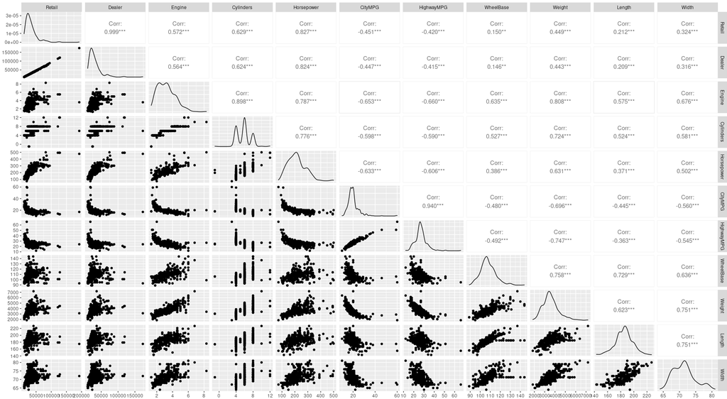

Scatter-plot

We can observe that some variables are highly correlated between each other. It is the case of the pairs Retail-Dealer, HighwayMPG-CityMPG, and Cylinder-Engine which makes sense given the meaning of such variables in the context of the data:

- Retail: Suggested retail price (US)
- Dealer: Price to dealer (US)
- CityMPG: City gas mileage
- HighwayMPG: Highway gas mileage
- -Cylinder: Number of engine cylinders
- Engine: Engine size

This is a good scenario for applying PCA, since the goal of the method is to capture and remove the redundances contained in the date.

From the scatter plot, it seems like there are several outliers that need to be handled in order to improve the quality of the dataset.

To delete such points we use a utility function which, for each numerical column, detects the points outside the interquartile range via the *boxplot.stats( )* informations, and defines them as NA points.

```r
library(dplyr)
library(purrr) # functional programming package
```

```r
# first we copy the original dataframe
pp_cars <- data.frame(cars)

# utility function
outlierreplacement <- function(dataframe){
   dataframe %>%
           map_if(is.numeric, ~ replace(.x, .x %in% boxplot.stats(.x)$out, NA)) %>%
           bind_cols
}

# apply function to our dataset
na_cars <- outlierreplacement(pp_cars)
```

The outliers have been transformed into NA values.

As we did before, we can transform such values into the mean of the columns to which they belong to

First we have to check another time the columns in which we have NA values.

We will use the dataframe without the categorical variables (na_cars), this has to be done because otherwise a lot of values in the categorical variable are identified as ‘outliers’ even though in such columns we have only the values 0 and 1

```r
print("Number of NA values in each column:")
```

```
[1] "Number of NA values in each column:"
```

```r
for(name in names(na_cars)){
  print(paste(name,  ": ", sum(is.na(na_cars[, name]))))
}
```

```
[1] "Retail :  27"
[1] "Dealer :  27"
[1] "Engine :  2"
[1] "Cylinders :  7"
[1] "Horsepower :  7"
[1] "CityMPG :  29"
[1] "HighwayMPG :  23"
[1] "WheelBase :  19"
[1] "Weight :  15"
[1] "Length :  16"
[1] "Width :  3"
```

```r
print("--------------------------------------------------------------------")
```

```
[1] "--------------------------------------------------------------------"
```

```r
print("Mean of the NA values in each column:")
```

```
[1] "Mean of the NA values in each column:"
```

```r
for(name in names(na_cars)){
  print(paste(name, ": ", mean(is.na(na_cars[, name]))))
}
```

```
[1] "Retail :  0.0630841121495327"
[1] "Dealer :  0.0630841121495327"
[1] "Engine :  0.00467289719626168"
[1] "Cylinders :  0.0163551401869159"
[1] "Horsepower :  0.0163551401869159"
[1] "CityMPG :  0.0677570093457944"
[1] "HighwayMPG :  0.0537383177570093"
[1] "WheelBase :  0.044392523364486"
[1] "Weight :  0.0350467289719626"
[1] "Length :  0.0373831775700935"
[1] "Width :  0.00700934579439252"
```

After this, we can substitute the NA values as explained above.

```r
# now we substitute with the mean the NA values in the numerical variables

retail_mean <- mean(na_cars$Retail, na.rm = TRUE)
dealer_mean <- mean(na_cars$Dealer, na.rm = TRUE)
engine_mean <- mean(na_cars$Engine, na.rm = TRUE)
cylinders_mean <- mean(na_cars$Cylinders, na.rm = TRUE)
horsepower_mean <- mean(na_cars$Horsepower, na.rm = TRUE)

citympg_mean <- mean(na_cars$CityMPG, na.rm = TRUE)
highwaympg_mean <- mean(na_cars$HighwayMPG, na.rm = TRUE)
weight_mean <- mean(na_cars$Weight, na.rm = TRUE)
wheelbase_mean <- mean(na_cars$WheelBase, na.rm = TRUE)
lenght_mean <- mean(na_cars$Length, na.rm = TRUE)
width_mean <- mean(na_cars$Width, na.rm = TRUE)

na_cars$Retail[is.na(na_cars$Retail)] <- retail_mean
na_cars$Dealer[is.na(na_cars$Dealer)] <- dealer_mean
na_cars$Engine[is.na(na_cars$Engine)] <- engine_mean
na_cars$Cylinders[is.na(na_cars$Cylinders)] <- cylinders_mean
na_cars$Horsepower[is.na(na_cars$Horsepower)] <- horsepower_mean

na_cars$CityMPG[is.na(na_cars$CityMPG)] <- citympg_mean
na_cars$HighwayMPG[is.na(na_cars$HighwayMPG)] <- highwaympg_mean
na_cars$Weight[is.na(na_cars$Weight)] <- weight_mean
na_cars$WheelBase[is.na(na_cars$WheelBase)] <- wheelbase_mean
na_cars$Length[is.na(na_cars$Length)] <- lenght_mean
na_cars$Width[is.na(na_cars$Width)] <- width_mean
```

Let’s see if we have correctly removed NAs:

```r
print("Number of NA values in each column:")
```

```
[1] "Number of NA values in each column:"
```

```r
for(name in names(na_cars)){
  print(paste(name,  ": ", sum(is.na(na_cars[, name]))))
}
```

```
[1] "Retail :  0"
[1] "Dealer :  0"
[1] "Engine :  0"
[1] "Cylinders :  0"
[1] "Horsepower :  0"
[1] "CityMPG :  0"
[1] "HighwayMPG :  0"
[1] "WheelBase :  0"
[1] "Weight :  0"
[1] "Length :  0"
[1] "Width :  0"
```

```r
print("--------------------------------------------------------------------")
```

```
[1] "--------------------------------------------------------------------"
```

```r
print("Mean of the NA values in each column:")
```

```
[1] "Mean of the NA values in each column:"
```

```r
for(name in names(na_cars)){
  print(paste(name, ": ", mean(is.na(na_cars[, name]))))
}
```

```
[1] "Retail :  0"
[1] "Dealer :  0"
[1] "Engine :  0"
[1] "Cylinders :  0"
[1] "Horsepower :  0"
[1] "CityMPG :  0"
[1] "HighwayMPG :  0"
[1] "WheelBase :  0"
[1] "Weight :  0"
[1] "Length :  0"
[1] "Width :  0"
```

To see the effects that the elimination of the outliers has produced let’s plot a box plot for each variable. It seems like some outliers are still present in the dataset, but the number is much smaller then before.

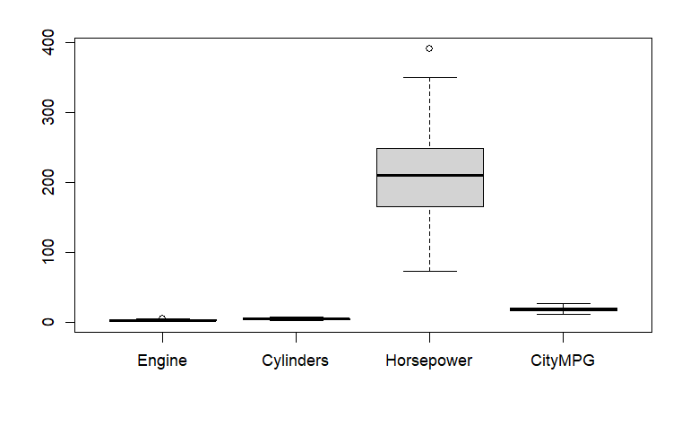

```r
boxplot(na_cars$Engine,
        na_cars$Cylinders, na_cars$Horsepower, na_cars$CityMPG,
        names=c("Engine", "Cylinders", "Horsepower",
                "CityMPG"))
```

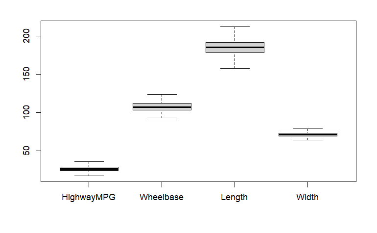

```r
boxplot(na_cars$HighwayMPG, na_cars$WheelBase, na_cars$Length, na_cars$Width,
        names=c("HighwayMPG","Wheelbase", "Length", "Width"))
```

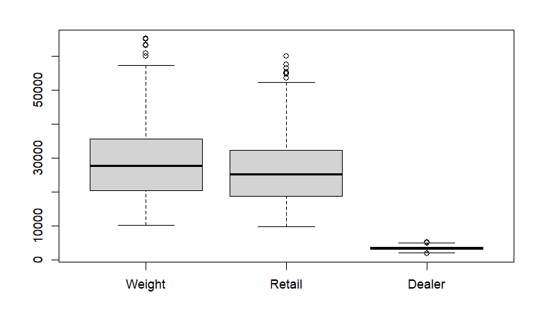

```r
boxplot(na_cars$Retail, na_cars$Dealer, na_cars$Weight,
        names=c("Weight", "Retail", "Dealer"))
```

Let’s see how the scatter plot has changes

[output not shown]

[output cut: 66 more lines]

[output not shown]

[figure not shown]

```r
x11(width = 20, height = 15)
ggpairs(na_cars)
```

```r
Sys.sleep(10)
```

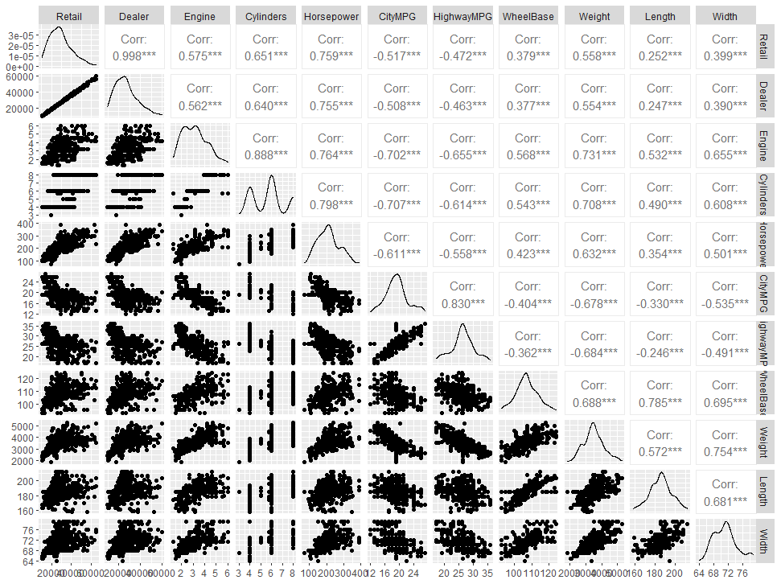

We put above the image of the plot since the one generated by R overlaps.

## PCA

Now that the pre-processing phase has been completed, we can start applying PCA in order to reduce the dimensionality of the dataset.

The first thing to observe is that the columns work on very different scales, for example the variables ‘Weigth’, ‘Retail’ and ‘Dealer’ have values much greater that the other columns, therefore, it is necessary to extract the PCs from the correlation matrix **R**.; in that way we don’t need to center the data set.

We’ll use the ‘princomp()’ function of the ‘R stats’ package, by specifying the parameter ‘cor’ to indicate the function to use the correlation matrix.

```r
### PCA
cars_pca <- princomp(na_cars, cor=TRUE)
```

The result of the above function is a list containing the various elements defining the PCs:

```r
str(cars_pca)
```

```
List of 7
 $ sdev    : Named num [1:11] 2.618 1.243 0.983 0.7 0.556 ...
  ..- attr(*, "names")= chr [1:11] "Comp.1" "Comp.2" "Comp.3" "Comp.4" ...
 $ loadings: 'loadings' num [1:11, 1:11] 0.291 0.288 0.34 0.341 0.319 ...
  ..- attr(*, "dimnames")=List of 2
  .. ..$ : chr [1:11] "Retail" "Dealer" "Engine" "Cylinders" ...
  .. ..$ : chr [1:11] "Comp.1" "Comp.2" "Comp.3" "Comp.4" ...
 $ center  : Named num [1:11] 29041.29 26610.54 3.18 5.74 211.57 ...
  ..- attr(*, "names")= chr [1:11] "Retail" "Dealer" "Engine" "Cylinders" ...
 $ scale   : Named num [1:11] 11259.68 10111.1 1.07 1.43 63.39 ...
  ..- attr(*, "names")= chr [1:11] "Retail" "Dealer" "Engine" "Cylinders" ...
 $ n.obs   : int 428
 $ scores  : num [1:428, 1:11] -4.75 -4.32 -3.38 -3.43 -3.29 ...
  ..- attr(*, "dimnames")=List of 2
  .. ..$ : NULL
  .. ..$ : chr [1:11] "Comp.1" "Comp.2" "Comp.3" "Comp.4" ...
 $ call    : language princomp(x = na_cars, cor = TRUE)
 - attr(*, "class")= chr "princomp"
```

### Visualization and Interpretation

Let’ s now check the results one by one

### Loadings

The coefficients (also called loadings or loading vector) for the first PC are obtained as:

```r
l1 <- cars_pca$loadings[, 1]
l1
```

```
    Retail     Dealer     Engine  Cylinders Horsepower    CityMPG HighwayMPG  WheelBase     Weight     Length      Width
 0.2910003  0.2880567  0.3399190  0.3410232  0.3194061 -0.3036512 -0.2838038  0.2693381  0.3340004  0.2353079  0.2937046
```

The vector has to be orthonormal, we can check this computing the dot product of the vector with itself:

```r
l1%*%l1
```

```
     [,1]
[1,]    1
```

And now we can check that all the loading vectors are orthogonal between each other, computing the loading vector for the second PC and then applying the dot product with the loading vector computed above.

```r
l2 <- cars_pca$loadings[, 2]

l1%*%l2
```

```
              [,1]
[1,] -4.163336e-17
```

It’s important to rescale the loadings, so that the coefficients of the most important components are larger than those of less important ones. I

In order to rescale the loadings we use the standard deviations of the principal components.

The rescaled loadings for the 1st PC are calculated as:

```r
rescaledl1 <- l1 * cars_pca$sdev[1]
rescaledl1
```

```
    Retail     Dealer     Engine  Cylinders Horsepower    CityMPG HighwayMPG  WheelBase     Weight     Length      Width
 0.7618039  0.7540979  0.8898670  0.8927578  0.8361667 -0.7949222 -0.7429642  0.7050948  0.8743730  0.6160077  0.7688833
```

### Explained Variance

First we print the summary function, to obtain for each component it’s standard deviation, the proportion of variance explained and the cumulative proportion of variance

```r
summary(cars_pca)
```

```
Importance of components:
                          Comp.1    Comp.2     Comp.3     Comp.4     Comp.5     Comp.6     Comp.7     Comp.8    Comp.9
Standard deviation     2.6178797 1.2425585 0.98284809 0.70027729 0.55622936 0.48619602 0.43163692 0.40473031 0.3911495
Proportion of Variance 0.6230267 0.1403592 0.08781731 0.04458075 0.02812646 0.02148969 0.01693731 0.01489151 0.0139089
Cumulative Proportion  0.6230267 0.7633860 0.85120330 0.89578405 0.92391052 0.94540020 0.96233752 0.97722903 0.9911379
                           Comp.10      Comp.11
Standard deviation     0.309932357 0.0377454938
Proportion of Variance 0.008732551 0.0001295202
Cumulative Proportion  0.999870480 1.0000000000
```

We can observe that the first component explains alone a considerable proportion of the whole variability of the dataset (around 60%) and together with the second component the amount of explained variability rises to 76 %. This means that probably, we will be able to summarize the whole dataset using only the two obtained components.

Let’s plot the proportion of explained variance by means of a scree plot

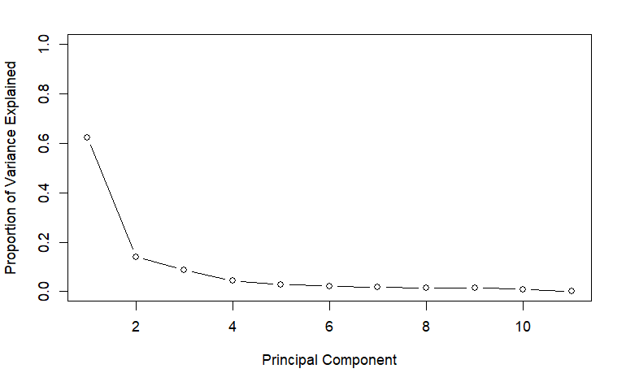

```r
# compute the percentage of variance explained for each component
pr.var <- cars_pca$sdev^2
pve <- pr.var/sum(pr.var)

# Plot
plot(pve, xlab="Principal Component",
ylab="Proportion of Variance Explained",
ylim=c(0,1),type='b')
```

Then we can simply obtain and plot the cumulative proportion of variance

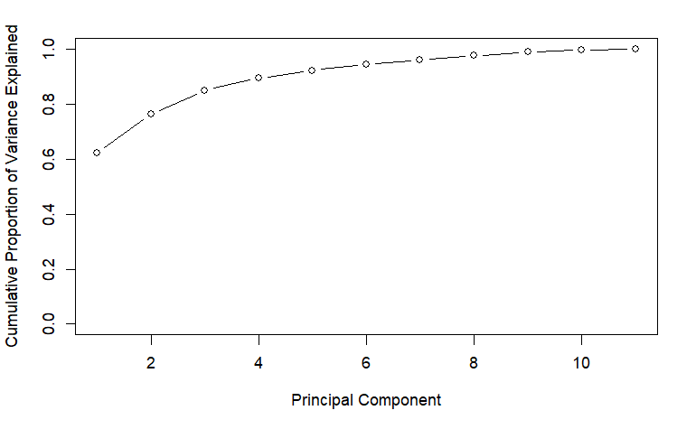

```r
plot(cumsum(pve), xlab="Principal Component",
ylab="Cumulative Proportion of Variance Explained",
ylim=c(0,1),type='b')
```

### Choosing the number of components

Now we should choose the number of components with which we want to explain our data. To do so it is useful to understand which are the components that retain the majority of the variability.

A good graphical indicator is the scree plot, which plots the variance explain by each component. To do such plot we load the ‘factoextra’ library:

```r
library(factoextra)
```

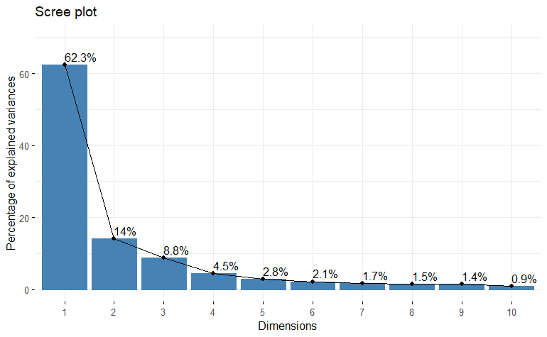

```r
fviz_eig(cars_pca, addlabels = TRUE, ylim = c(0, 70))
```

As stated before, the first and the second component alone explain almost 80% of the variance pf the whole data points, therefore, they are the main candidate to summarize the information of the data.

When looking at the scree plot, it is important to look for elbows, which means a point after which the eigenvalues start decrease more slowly. As we can see from the plot, the elbow appears passing from the second to the third dimension.

It is useful to use the ‘get_pca_var()’ function of the ‘factoextra’ package, which provides a list of matrices containing all the results for the active variables (coordinates, correlation between variables and axes, squared cosine and contributions) which we will then print.

```r
var <- get_pca_var(cars_pca)
var
```

```
Principal Component Analysis Results for variables
 ===================================================
  Name       Description
1 "$coord"   "Coordinates for the variables"
2 "$cor"     "Correlations between variables and dimensions"
3 "$cos2"    "Cos2 for the variables"
4 "$contrib" "contributions of the variables"
```

### Loading Plot

We can observe the loadings for each PC.

```r
# Coordinates of variables
head(var$coord, 11)
```

```
                Dim.1       Dim.2         Dim.3       Dim.4       Dim.5       Dim.6       Dim.7       Dim.8       Dim.9
Retail      0.7618039  0.48294562  0.3818762894  0.17377097  0.02043650  0.06156852  0.05593606  0.03688573  0.02886462
Dealer      0.7540979  0.48595728  0.3910297262  0.18347864  0.02349721  0.05536249  0.04943963  0.03501461  0.02196213
Engine      0.8898670 -0.02073404 -0.1182650576 -0.34235835 -0.01415899 -0.05219040  0.10658962  0.08613516  0.12286578
Cylinders   0.8927578  0.08074864 -0.0363517650 -0.34258854  0.02602893 -0.02452819  0.17376623  0.01824641 -0.04725720
Horsepower  0.8361667  0.30508761  0.1247310685 -0.25343187 -0.06410411 -0.06148598 -0.31309049 -0.14409154 -0.03581965
CityMPG    -0.7949222 -0.13489721  0.4665469991 -0.08933606 -0.15239408 -0.19829446 -0.05291200  0.12320460  0.19672864
HighwayMPG -0.7429642 -0.15593298  0.5455060974 -0.21589629 -0.09034155  0.03477764  0.10269547 -0.05622750 -0.22388191
WheelBase   0.7050948 -0.53933616  0.2301484185  0.14201407  0.20672642 -0.20579826  0.07268543 -0.21353780  0.05240538
Weight      0.8743730 -0.17613499 -0.0992104250  0.19900079 -0.15072516 -0.25257337 -0.03303539  0.17469051 -0.19153669
Length      0.6160077 -0.65281112  0.2415288692 -0.05321483  0.19804962  0.21288348 -0.14089881  0.16827294 -0.01241742
Width       0.7688833 -0.42889434 -0.0007089535  0.10261769 -0.40910991  0.17443940  0.03978168 -0.09966752  0.06824983
                  Dim.10        Dim.11
Retail      0.0120840353  2.675042e-02
Dealer      0.0116221153 -2.661578e-02
Engine      0.1992730606 -5.048615e-04
Cylinders  -0.2091285071 -2.723363e-04
Horsepower  0.0005376121  2.930385e-04
CityMPG    -0.0709121071 -2.977534e-05
HighwayMPG  0.0793654818  1.708571e-04
WheelBase   0.0102402645  2.158865e-04
Weight      0.0140837666  3.882397e-04
Length     -0.0184034290 -1.924852e-05
Width      -0.0190495704 -3.080712e-04
```

The second component has a large positive association with Retail and Dealer, which means that it describes the most expensive cars. It has also positive association with cylinders and horsepower, this, with the above results, may suggests that this component is associated with Sports car.

Now we plot the correlation circle to show it better:

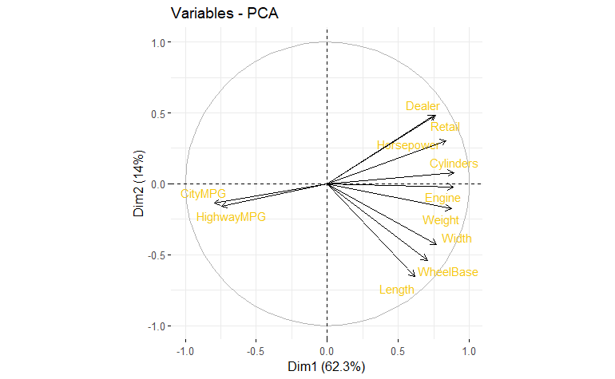

```r
fviz_pca_var(cars_pca, col.var = "black", labelsize = 2.5, repel = TRUE)
```

The plot above shows the relationships between all variables. It can be interpreted as follow:

- Positively correlated variables are grouped together.
- Negatively correlated variables are positioned on opposite sides of the plot origin (opposed quadrants).
- The distance between variables and the origin measures the quality of the variables. Variables that are away from the origin are well represented on the plot.

The plot confirms the highly correlation observed before in the scatter plot.

#### Quality of representation

The quality of representation of the variables on factor map is called cos2 (square cosine, squared coordinates). We can use the corrplot package to visualize the cos2

```r
head(var$cos2, 4)
```

```
              Dim.1        Dim.2       Dim.3      Dim.4        Dim.5        Dim.6       Dim.7        Dim.8        Dim.9
Retail    0.5803452 0.2332364761 0.145829500 0.03019635 0.0004176504 0.0037906821 0.003128843 0.0013605569 0.0008331664
Dealer    0.5686636 0.2361544759 0.152904247 0.03366441 0.0005521189 0.0030650049 0.002444277 0.0012260232 0.0004823351
Engine    0.7918633 0.0004299005 0.013986624 0.11720924 0.0002004769 0.0027238375 0.011361346 0.0074192651 0.0150959991
Cylinders 0.7970165 0.0065203427 0.001321451 0.11736691 0.0006775052 0.0006016319 0.030194704 0.0003329313 0.0022332434
                Dim.10       Dim.11
Retail    0.0001460239 7.155851e-04
Dealer    0.0001350736 7.083996e-04
Engine    0.0397097527 2.548852e-07
Cylinders 0.0437347325 7.416708e-08
```

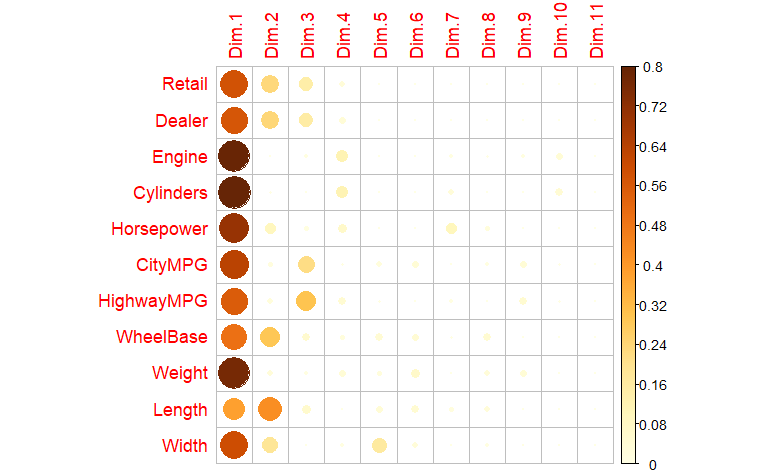

```r
library("corrplot")
corrplot(var$cos2, is.corr=FALSE)
```

As imagined, the first component is the best in representing the variables. It’s also possible to create a bar plot of variables cos2 using the function fviz_cos2

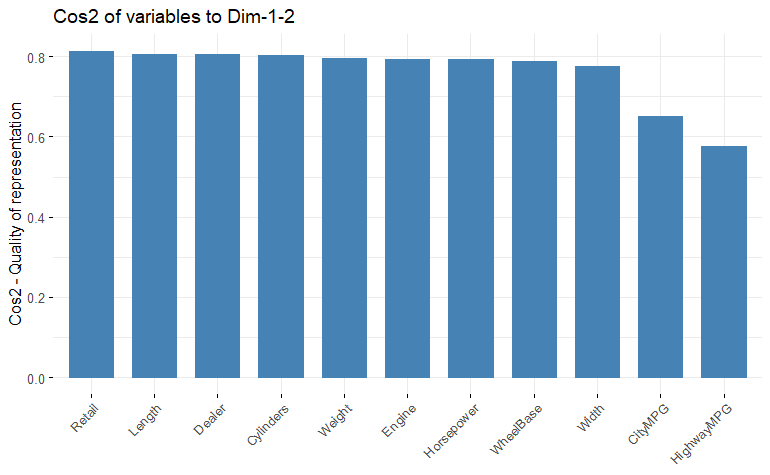

```r
# Total cos2 of variables on Dim.1 and Dim.2
fviz_cos2(cars_pca, choice = "var", axes = 1:2)
```

- A high cos2 indicates a good representation of the variable on the principal component. In this case the variable is positioned close to the circumference of the correlation circle.
- A low cos2 indicates that the variable is not perfectly represented by the PCs. In this case the variable is close to the center of the circle.

For a given variable, the sum of the cos2 on all the principal components is equal to one.

If a variable is perfectly represented by only two principal components (Dim.1 & Dim.2), the sum of the cos2 on these two PCs is equal to one. In this case the variables will be positioned on the circle of correlations.

For some of the variables, more than 2 components might be required to perfectly represent the data. In this case the variables are positioned inside the circle of correlations.

It’s possible to color variables by their cos2 values using the argument col.var = “cos2”.

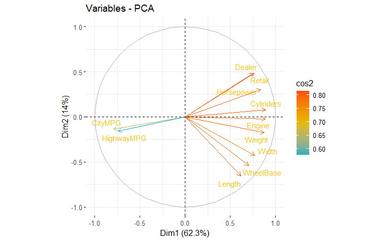

```r
# Color by cos2 values: quality on the factor map
fviz_pca_var(cars_pca, col.var = "cos2",
             gradient.cols = c("#00AFBB", "#E7B800", "#FC4E07"),
             repel = TRUE, labelsize = 2.5 # Avoid text overlapping
             )
```

### Contributions of variables to PCs

The contributions of variables in accounting for the variability in a given principal component are expressed in percentage.

- Variables that are correlated with PC1 (i.e., Dim.1) and PC2 (i.e., Dim.2) are the most important in explaining the variability in the data set.
- Variables that do not correlated with any PC or correlated with the last dimensions are variables with low contribution and might be removed to simplify the overall analysis.

```r
head(var$contrib, 11)
```

```
               Dim.1       Dim.2        Dim.3      Dim.4       Dim.5      Dim.6      Dim.7      Dim.8      Dim.9       Dim.10
Retail      8.468120 15.10646157 1.509637e+01  6.1576412  0.13499109  1.6035945  1.6793708  0.8305873  0.5445606 1.520163e-01
Dealer      8.297668 15.29545711 1.582875e+01  6.8648485  0.17845338  1.2966070  1.3119379  0.7484577  0.3152560 1.406166e-01
Engine     11.554492  0.02784417 1.447905e+00 23.9013134  0.06479724  1.1522810  6.0980729  4.5292828  9.8668002 4.133932e+01
Cylinders  11.629684  0.42231519 1.367975e-01 23.9334651  0.21898018  0.2545119 16.2066633  0.2032466  1.4596560 4.552947e+01
Horsepower 10.202023  6.02858550 1.610558e+00 13.0973183  1.32820139  1.5992981 52.6141531 12.6749293  0.8386043 3.008875e-04
CityMPG     9.220403  1.17861569 2.253295e+01  1.6274718  7.50634285 16.6340634  1.5026961  9.2666427 25.2958725 5.234883e+00
HighwayMPG  8.054460  1.57486113 3.080537e+01  9.5049594  2.63795421  0.5116552  5.6606379  1.9300391 32.7606483 6.557367e+00
WheelBase   7.254302 18.84019307 5.483315e+00  4.1126585 13.81287722 17.9168062  2.8356824 27.8367204  1.7950071 1.091663e-01
Weight     11.155630  2.00935903 1.018924e+00  8.0755016  7.34283339 26.9868581  0.5857626 18.6297570 23.9783024 2.064923e-01
Length      5.536979 27.60205207 6.039004e+00  0.5774644 12.67769205 19.1717226 10.6555902 17.2861044  0.1007807 3.525849e-01
Width       8.626239 11.91425548 5.203106e-05  2.1473578 54.09687699 12.8726020  0.8494330  6.0642329  3.0445118 3.777779e-01
                 Dim.11
Retail     5.022628e+01
Dealer     4.972194e+01
Engine     1.789017e-02
Cylinders  5.205722e-03
Horsepower 6.027248e-03
CityMPG    6.222764e-05
HighwayMPG 2.048971e-03
WheelBase  3.271303e-03
Weight     1.057961e-02
Length     2.600546e-05
Width      6.661499e-03
```

It’s possible to use the function ‘corrplot()’ to highlight the most contributing variables for each dimension:

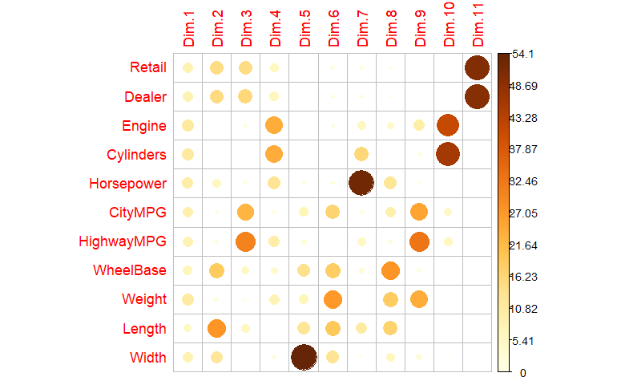

```r
corrplot(var$contrib, is.corr=FALSE)
```

As we can see all the variables contributes more or less in the same way to the first dimension, while for the other dimensions there are unbalanced contributions in determining the PCs. So it seems like there aren’t variables that can be discarded to simplify the overall analysis.

The function fviz_contrib() can be used to draw a bar plot of variable contributions.

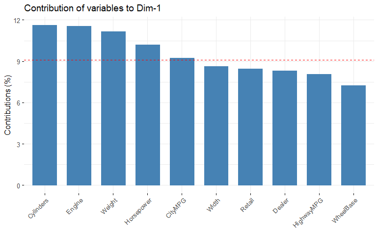

```r
# Contributions of variables to PC1
fviz_contrib(cars_pca, choice = "var", axes = 1, top = 10)
```

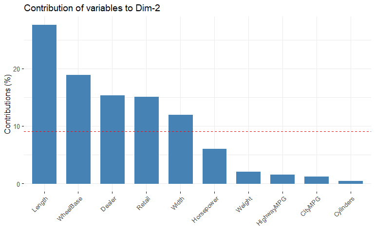

```r
# Contributions of variables to PC2
fviz_contrib(cars_pca, choice = "var", axes = 2, top = 10)
```

The red dashed line on the graph above indicates the expected average contribution. For a given component, a variable with a contribution larger than this cutoff could be considered as important in contributing to the component. For the first dimension, almost every variable has a contribution around the red dashed line, while for the second dimension the contribution given by Length is not comparable with the one of Cylinders or CityMPG.

Now we can plot again the correlation circle, highlighting the most important variables for the first two dimensions.

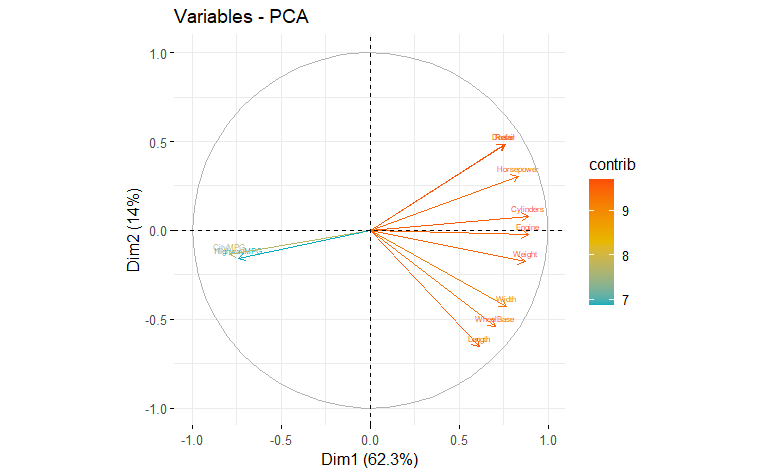

```r
fviz_pca_var(cars_pca, col.var = "contrib",
             gradient.cols = c("#00AFBB", "#E7B800", "#FC4E07"),
             labelsize = 2
             )
```

### Principal Component scores

The PC scores are the values of each PCs (linear combination of the original variables) evaluated in the data set.

```r
head(predict(cars_pca)) %>%
  kbl(caption = "PCA scores") %>%
  kable_classic(full_width = F, html_font = "Cambria")
```

PCA scores

| Comp.1 | Comp.2 | Comp.3 | Comp.4 | Comp.5 | Comp.6 | Comp.7 | Comp.8 | Comp.9 | Comp.10 | Comp.11 |
| --- | --- | --- | --- | --- | --- | --- | --- | --- | --- | --- |
| -4.745984 | 0.3994584 | -0.7308411 | -0.3395705 | 0.3223562 | 0.4184159 | 0.7437991 | -0.6016117 | -0.9797073 | 0.2977211 | 0.0103553 |
| -4.319604 | -0.4054732 | -0.2550816 | -0.4343770 | 0.9299903 | 1.1837491 | 0.2237446 | 0.0887011 | -1.0048496 | 0.2036522 | 0.0071099 |
| -3.380559 | -0.8125141 | 0.0586200 | -0.0779775 | -0.0008481 | -0.3420334 | -0.4591238 | 0.3612503 | 1.4464502 | -0.4149734 | -0.0087511 |
| -3.430932 | -0.7033502 | 0.0636501 | -0.0880839 | 0.2059852 | -0.4989195 | -0.4907921 | 0.4821711 | 1.3481792 | -0.3900448 | -0.0056795 |
| -3.287393 | -0.6870351 | 0.1851884 | 0.0041563 | 0.0118792 | -0.3033762 | -0.4198902 | 0.3898207 | 1.4673014 | -0.4026706 | -0.0127961 |
| -3.862483 | -0.3697403 | 0.0681276 | -0.4343836 | 0.4992817 | 0.1569444 | 0.6434898 | -0.9592688 | -1.1435850 | 0.6725223 | 0.0110541 |

The PCs should be uncorrelated

```r
cor(cars_pca$scores) %>%
  kbl(caption = "PCA scores") %>%
  kable_classic(full_width = F, html_font = "Cambria")
```

PCA scores

|  | Comp.1 | Comp.2 | Comp.3 | Comp.4 | Comp.5 | Comp.6 | Comp.7 | Comp.8 | Comp.9 | Comp.10 | Comp.11 |
| --- | --- | --- | --- | --- | --- | --- | --- | --- | --- | --- | --- |
| Comp.1 | 1 | 0 | 0 | 0 | 0 | 0 | 0 | 0 | 0 | 0 | 0 |
| Comp.2 | 0 | 1 | 0 | 0 | 0 | 0 | 0 | 0 | 0 | 0 | 0 |
| Comp.3 | 0 | 0 | 1 | 0 | 0 | 0 | 0 | 0 | 0 | 0 | 0 |
| Comp.4 | 0 | 0 | 0 | 1 | 0 | 0 | 0 | 0 | 0 | 0 | 0 |
| Comp.5 | 0 | 0 | 0 | 0 | 1 | 0 | 0 | 0 | 0 | 0 | 0 |
| Comp.6 | 0 | 0 | 0 | 0 | 0 | 1 | 0 | 0 | 0 | 0 | 0 |
| Comp.7 | 0 | 0 | 0 | 0 | 0 | 0 | 1 | 0 | 0 | 0 | 0 |
| Comp.8 | 0 | 0 | 0 | 0 | 0 | 0 | 0 | 1 | 0 | 0 | 0 |
| Comp.9 | 0 | 0 | 0 | 0 | 0 | 0 | 0 | 0 | 1 | 0 | 0 |
| Comp.10 | 0 | 0 | 0 | 0 | 0 | 0 | 0 | 0 | 0 | 1 | 0 |
| Comp.11 | 0 | 0 | 0 | 0 | 0 | 0 | 0 | 0 | 0 | 0 | 1 |

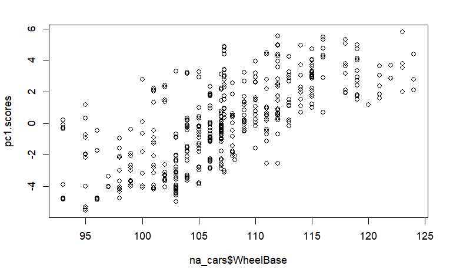

```r
pc1.scores <- cars_pca$scores[,1]
plot(na_cars$WheelBase, pc1.scores)
```

From the above plot it seems like the first PC manages to explain the considered variable, also if not perfectly defined, we can observe a linear relationship between the two.

Now, given the scores of each entry of the dataset, it is possible to visualize the Score Plot, which shows clusters of cars based on their similarity. First, we visualize the scores of the dataset.

```r
rbind(cars_pca$scores[,1], cars_pca$scores[,2])
```

[output not shown]

[output cut: 62 more lines]

[output not shown]

Due to the large amount of data points at disposal, it would be impossible to label each point in the graph. Therefore, we can use the supplementary categorical variables, represented by the model type of the car, to color each point. Before doing so, it is necessary to collapse all the binary variables regarding the model type, in one labelling variable.

```r
#Sports SUV Wagon   Minivan Pickup  AWD RWD

cars_lab = read_csv("cars2004.csv")
# need to remove again the NA values
value <- tail(names(sort(table(cars_lab$Sports))), 1)
cars_lab$Sports[is.na(cars_lab$Sports)] <- value

model <- c()

for(i in 1:nrow(cars_lab)){

  if(cars_lab[i, "Sports"] == 1){
    model <- c(model, "Sport")
  }
  else if(cars_lab[i, "SUV"] == 1){
    model <- c(model, "SUV")

  }
  else if(cars_lab[i, "Wagon"] == 1){
    model <- c(model, "Wagon")

  }
  else if(cars_lab[i, "Minivan"] == 1){
    model <- c(model, "Minivan")

  }
  else if(cars_lab[i, "Pickup"] == 1){
    model <- c(model, "Pickup")

  }
  else{
    model <- c(model, "Other")
  }
  #else if(cars_lab[i, "AWD"] == 1){
   # model <- c(model, "AWD")

  #}
  #else{

   # model <- c(model, "RWD")
  #}
}

cars_lab["Model"] <- model
```

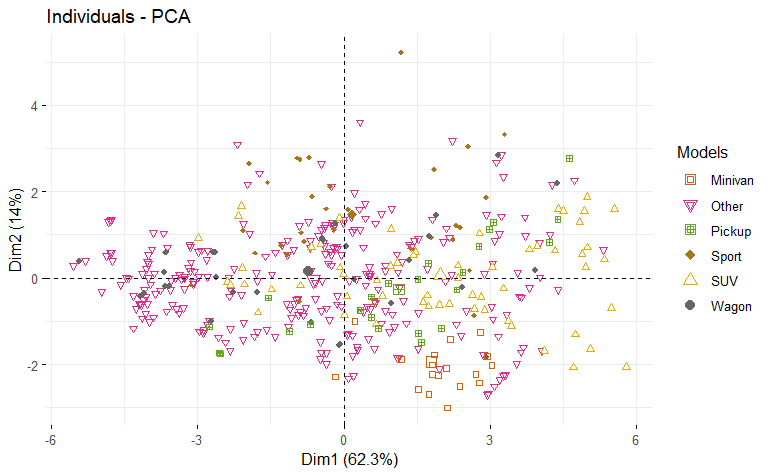

```r
fviz_pca_ind(cars_pca,
             geom.ind = "point", # show points only (nbut not "text")
             col.ind = cars_lab$Model, # color by groups
             palette = c("#D95F02", "#E7298A", "#66A61E", "#A6761D",
                         "#E6AB02", "#666666", "#7570B3"),
             addEllipses = FALSE, # Concentration ellipses
             legend.title = "Models"
             ) + scale_shape_manual(values=c(0, 6, 12, 18, 24, 19 ,25)) #change shapes
```

As we can observe the data are quite spread along each directions. The most significant cluster that can be observed is the one representing the cars of the Minivan type in the bottom-right corner. Moreover we can observe a majority of the SUV type of cars laying in the first and fourth quadrant of the graph.

### Biplot

Finally we draw the biplot, which is the combination of the PCA score plot, together with the loading plot.

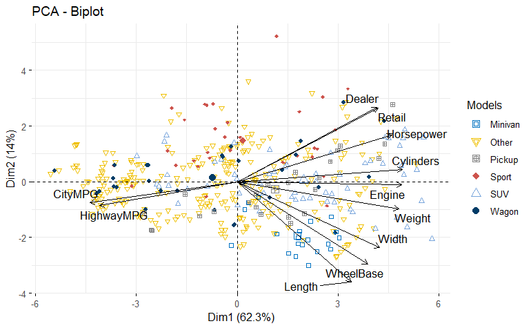

```r
fviz_pca_biplot(cars_pca,
                col.ind = cars_lab$Model, palette = "jco",
                addEllipses = FALSE, label = "var",
                col.var = "black", repel = TRUE,
                legend.title = "Models")+ scale_shape_manual(values=c(0, 6, 12, 18, 24, 19 ,25))
```

As we can see the Minivan type of cars are depicted together with the Length, Wheelbase and Width variables, which make sense considering that this type of car is the one having the greatest values regarding these attributes. Also the SUV type of cars are partially together in a cluster, and are near the Engine, Cylinders and Horsepower variables, which is coherent given the kind of car. Even if not perfectly represented, the Sports car are more spreaded in the first quadrant, where Dealer and Retail variables are pointing, which is coherent with the fact that these kind of cars are usually the most expensive one.

Let’s see another possible version of the biplot in which we are trying to color both the individuals and the groups. Specifically the groups are colored based on their contributions.

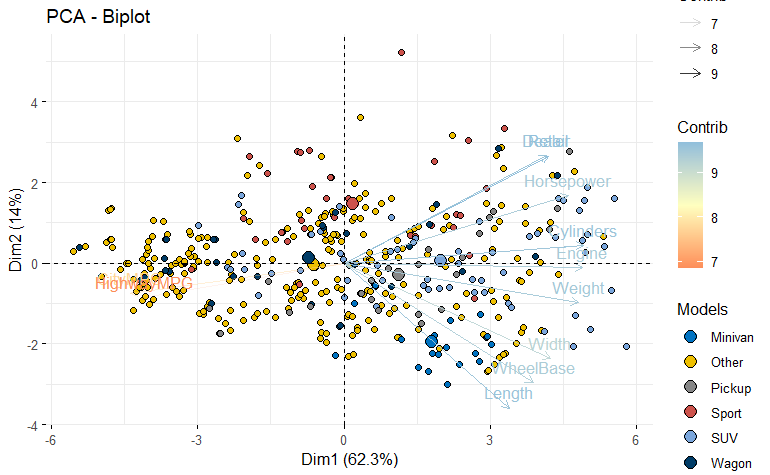

```r
fviz_pca_biplot(cars_pca,
                # Individuals
                geom.ind = "point",
                fill.ind = cars_lab$Model, col.ind = "black",
                pointshape = 21, pointsize = 2,
                palette = "jco",
                #addEllipses = TRUE,
                # Variables
                alpha.var ="contrib", col.var = "contrib",
                gradient.cols = "RdYlBu",
                legend.title = list(fill = "Models", color = "Contrib",
                                    alpha = "Contrib")
                )
```

As we observed also before, the less contributing variables are HighwayMPG and CityMPG.